# Optimal Treatment Analysis

## Outcome Variable

**Outcome Variable:** ever_stunted

## Predictor Variables

**Intervention Variable:** exclfeed36

**Adjustment Set:**

- arm
- sex
- W_mage
- meducyrs
- feducyrs
- hhwealth_quart
- hfoodsec
- W_mhtcm
- vagbrth
- W_gagebrth
- W_birthwt
- W_birthlen
- W_nrooms
- W_nchldlt5
- month
- brthmon
- W_parity
- impfloor
- impsan
- safeh20
- delta_W_mage
- delta_meducyrs
- delta_feducyrs
- delta_hhwealth_quart
- delta_hfoodsec
- delta_W_mhtcm
- delta_vagbrth
- delta_W_gagebrth
- delta_W_birthwt
- delta_W_birthlen
- delta_W_nrooms
- delta_W_nchldlt5
- delta_month
- delta_brthmon
- delta_W_parity
- delta_impfloor
- delta_impsan
- delta_safeh20

## Stratifying Variables

The analysis was stratified on these variable(s):

- agecat
- studyid
- country

## Data Summary

| agecat | studyid | country | exclfeed36 | ever_stunted | n_cell | n |
| --- | --- | --- | --- | --- | --- | --- |
| 0-24 months (no birth st.) | ki0047075b-MAL-ED | BANGLADESH | 1 | 0 | 24 | 209 |
| 0-24 months (no birth st.) | ki0047075b-MAL-ED | BANGLADESH | 1 | 1 | 29 | 209 |
| 0-24 months (no birth st.) | ki0047075b-MAL-ED | BANGLADESH | 0 | 0 | 74 | 209 |
| 0-24 months (no birth st.) | ki0047075b-MAL-ED | BANGLADESH | 0 | 1 | 82 | 209 |
| 0-24 months (no birth st.) | ki0047075b-MAL-ED | BRAZIL | 1 | 0 | 13 | 202 |
| 0-24 months (no birth st.) | ki0047075b-MAL-ED | BRAZIL | 1 | 1 | 1 | 202 |
| 0-24 months (no birth st.) | ki0047075b-MAL-ED | BRAZIL | 0 | 0 | 161 | 202 |
| 0-24 months (no birth st.) | ki0047075b-MAL-ED | BRAZIL | 0 | 1 | 27 | 202 |
| 0-24 months (no birth st.) | ki0047075b-MAL-ED | INDIA | 1 | 0 | 2 | 202 |
| 0-24 months (no birth st.) | ki0047075b-MAL-ED | INDIA | 1 | 1 | 2 | 202 |
| 0-24 months (no birth st.) | ki0047075b-MAL-ED | INDIA | 0 | 0 | 92 | 202 |
| 0-24 months (no birth st.) | ki0047075b-MAL-ED | INDIA | 0 | 1 | 106 | 202 |
| 0-24 months (no birth st.) | ki0047075b-MAL-ED | NEPAL | 1 | 0 | 11 | 211 |
| 0-24 months (no birth st.) | ki0047075b-MAL-ED | NEPAL | 1 | 1 | 4 | 211 |
| 0-24 months (no birth st.) | ki0047075b-MAL-ED | NEPAL | 0 | 0 | 145 | 211 |
| 0-24 months (no birth st.) | ki0047075b-MAL-ED | NEPAL | 0 | 1 | 51 | 211 |
| 0-24 months (no birth st.) | ki0047075b-MAL-ED | PERU | 1 | 0 | 5 | 252 |
| 0-24 months (no birth st.) | ki0047075b-MAL-ED | PERU | 1 | 1 | 9 | 252 |
| 0-24 months (no birth st.) | ki0047075b-MAL-ED | PERU | 0 | 0 | 97 | 252 |
| 0-24 months (no birth st.) | ki0047075b-MAL-ED | PERU | 0 | 1 | 141 | 252 |
| 0-24 months (no birth st.) | ki0047075b-MAL-ED | SOUTH AFRICA | 1 | 0 | 0 | 252 |
| 0-24 months (no birth st.) | ki0047075b-MAL-ED | SOUTH AFRICA | 1 | 1 | 0 | 252 |
| 0-24 months (no birth st.) | ki0047075b-MAL-ED | SOUTH AFRICA | 0 | 0 | 115 | 252 |
| 0-24 months (no birth st.) | ki0047075b-MAL-ED | SOUTH AFRICA | 0 | 1 | 137 | 252 |
| 0-24 months (no birth st.) | ki0047075b-MAL-ED | TANZANIA, UNITED REPUBLIC OF | 1 | 0 | 0 | 214 |
| 0-24 months (no birth st.) | ki0047075b-MAL-ED | TANZANIA, UNITED REPUBLIC OF | 1 | 1 | 1 | 214 |
| 0-24 months (no birth st.) | ki0047075b-MAL-ED | TANZANIA, UNITED REPUBLIC OF | 0 | 0 | 36 | 214 |
| 0-24 months (no birth st.) | ki0047075b-MAL-ED | TANZANIA, UNITED REPUBLIC OF | 0 | 1 | 177 | 214 |
| 0-24 months (no birth st.) | ki1000108-CMC-V-BCS-2002 | INDIA | 1 | 0 | 1 | 6 |
| 0-24 months (no birth st.) | ki1000108-CMC-V-BCS-2002 | INDIA | 1 | 1 | 5 | 6 |

[output cut: 174 more lines]

The following strata were considered:

- agecat: 0-24 months (no birth st.), studyid: ki0047075b-MAL-ED, country: BANGLADESH
- agecat: 0-24 months (no birth st.), studyid: ki0047075b-MAL-ED, country: BRAZIL
- agecat: 0-24 months (no birth st.), studyid: ki0047075b-MAL-ED, country: INDIA
- agecat: 0-24 months (no birth st.), studyid: ki0047075b-MAL-ED, country: NEPAL
- agecat: 0-24 months (no birth st.), studyid: ki0047075b-MAL-ED, country: PERU
- agecat: 0-24 months (no birth st.), studyid: ki0047075b-MAL-ED, country: SOUTH AFRICA
- agecat: 0-24 months (no birth st.), studyid: ki0047075b-MAL-ED, country: TANZANIA, UNITED REPUBLIC OF
- agecat: 0-24 months (no birth st.), studyid: ki1000108-CMC-V-BCS-2002, country: INDIA
- agecat: 0-24 months (no birth st.), studyid: ki1000108-IRC, country: INDIA
- agecat: 0-24 months (no birth st.), studyid: ki1000109-EE, country: PAKISTAN
- agecat: 0-24 months (no birth st.), studyid: ki1000304b-SAS-FoodSuppl, country: INDIA
- agecat: 0-24 months (no birth st.), studyid: ki1017093b-PROVIDE, country: BANGLADESH
- agecat: 0-24 months (no birth st.), studyid: ki1101329-Keneba, country: GAMBIA
- agecat: 0-24 months (no birth st.), studyid: ki1113344-GMS-Nepal, country: NEPAL
- agecat: 0-24 months (no birth st.), studyid: ki1148112-LCNI-5, country: MALAWI
- agecat: 0-24 months (no birth st.), studyid: kiGH5241-JiVitA-3, country: BANGLADESH
- agecat: 0-24 months (no birth st.), studyid: kiGH5241-JiVitA-4, country: BANGLADESH
- agecat: 0-6 months (no birth st.), studyid: ki0047075b-MAL-ED, country: BANGLADESH
- agecat: 0-6 months (no birth st.), studyid: ki0047075b-MAL-ED, country: BRAZIL
- agecat: 0-6 months (no birth st.), studyid: ki0047075b-MAL-ED, country: INDIA
- agecat: 0-6 months (no birth st.), studyid: ki0047075b-MAL-ED, country: NEPAL
- agecat: 0-6 months (no birth st.), studyid: ki0047075b-MAL-ED, country: PERU
- agecat: 0-6 months (no birth st.), studyid: ki0047075b-MAL-ED, country: SOUTH AFRICA
- agecat: 0-6 months (no birth st.), studyid: ki0047075b-MAL-ED, country: TANZANIA, UNITED REPUBLIC OF
- agecat: 0-6 months (no birth st.), studyid: ki1000108-CMC-V-BCS-2002, country: INDIA
- agecat: 0-6 months (no birth st.), studyid: ki1000108-IRC, country: INDIA
- agecat: 0-6 months (no birth st.), studyid: ki1000109-EE, country: PAKISTAN
- agecat: 0-6 months (no birth st.), studyid: ki1000304b-SAS-FoodSuppl, country: INDIA
- agecat: 0-6 months (no birth st.), studyid: ki1017093b-PROVIDE, country: BANGLADESH
- agecat: 0-6 months (no birth st.), studyid: ki1101329-Keneba, country: GAMBIA
- agecat: 0-6 months (no birth st.), studyid: ki1113344-GMS-Nepal, country: NEPAL
- agecat: 0-6 months (no birth st.), studyid: ki1148112-LCNI-5, country: MALAWI
- agecat: 0-6 months (no birth st.), studyid: kiGH5241-JiVitA-3, country: BANGLADESH
- agecat: 0-6 months (no birth st.), studyid: kiGH5241-JiVitA-4, country: BANGLADESH
- agecat: 6-24 months, studyid: ki0047075b-MAL-ED, country: BANGLADESH
- agecat: 6-24 months, studyid: ki0047075b-MAL-ED, country: BRAZIL
- agecat: 6-24 months, studyid: ki0047075b-MAL-ED, country: INDIA
- agecat: 6-24 months, studyid: ki0047075b-MAL-ED, country: NEPAL
- agecat: 6-24 months, studyid: ki0047075b-MAL-ED, country: PERU
- agecat: 6-24 months, studyid: ki0047075b-MAL-ED, country: SOUTH AFRICA
- agecat: 6-24 months, studyid: ki0047075b-MAL-ED, country: TANZANIA, UNITED REPUBLIC OF
- agecat: 6-24 months, studyid: ki1000108-CMC-V-BCS-2002, country: INDIA
- agecat: 6-24 months, studyid: ki1000108-IRC, country: INDIA
- agecat: 6-24 months, studyid: ki1000109-EE, country: PAKISTAN
- agecat: 6-24 months, studyid: ki1000304b-SAS-FoodSuppl, country: INDIA
- agecat: 6-24 months, studyid: ki1017093b-PROVIDE, country: BANGLADESH
- agecat: 6-24 months, studyid: ki1101329-Keneba, country: GAMBIA
- agecat: 6-24 months, studyid: ki1113344-GMS-Nepal, country: NEPAL
- agecat: 6-24 months, studyid: ki1148112-LCNI-5, country: MALAWI
- agecat: 6-24 months, studyid: kiGH5241-JiVitA-3, country: BANGLADESH
- agecat: 6-24 months, studyid: kiGH5241-JiVitA-4, country: BANGLADESH

### Dropped Strata

Some strata were dropped due to rare outcomes:

- agecat: 0-24 months (no birth st.), studyid: ki0047075b-MAL-ED, country: BRAZIL
- agecat: 0-24 months (no birth st.), studyid: ki0047075b-MAL-ED, country: INDIA
- agecat: 0-24 months (no birth st.), studyid: ki0047075b-MAL-ED, country: NEPAL
- agecat: 0-24 months (no birth st.), studyid: ki0047075b-MAL-ED, country: SOUTH AFRICA
- agecat: 0-24 months (no birth st.), studyid: ki0047075b-MAL-ED, country: TANZANIA, UNITED REPUBLIC OF
- agecat: 0-24 months (no birth st.), studyid: ki1000108-CMC-V-BCS-2002, country: INDIA
- agecat: 0-24 months (no birth st.), studyid: ki1000108-IRC, country: INDIA
- agecat: 0-24 months (no birth st.), studyid: ki1000304b-SAS-FoodSuppl, country: INDIA
- agecat: 0-6 months (no birth st.), studyid: ki0047075b-MAL-ED, country: BRAZIL
- agecat: 0-6 months (no birth st.), studyid: ki0047075b-MAL-ED, country: INDIA
- agecat: 0-6 months (no birth st.), studyid: ki0047075b-MAL-ED, country: NEPAL
- agecat: 0-6 months (no birth st.), studyid: ki0047075b-MAL-ED, country: SOUTH AFRICA
- agecat: 0-6 months (no birth st.), studyid: ki0047075b-MAL-ED, country: TANZANIA, UNITED REPUBLIC OF
- agecat: 0-6 months (no birth st.), studyid: ki1000108-CMC-V-BCS-2002, country: INDIA
- agecat: 0-6 months (no birth st.), studyid: ki1000108-IRC, country: INDIA
- agecat: 0-6 months (no birth st.), studyid: ki1000304b-SAS-FoodSuppl, country: INDIA
- agecat: 0-6 months (no birth st.), studyid: ki1148112-LCNI-5, country: MALAWI
- agecat: 6-24 months, studyid: ki0047075b-MAL-ED, country: BRAZIL
- agecat: 6-24 months, studyid: ki0047075b-MAL-ED, country: INDIA
- agecat: 6-24 months, studyid: ki0047075b-MAL-ED, country: NEPAL
- agecat: 6-24 months, studyid: ki0047075b-MAL-ED, country: PERU
- agecat: 6-24 months, studyid: ki0047075b-MAL-ED, country: SOUTH AFRICA
- agecat: 6-24 months, studyid: ki0047075b-MAL-ED, country: TANZANIA, UNITED REPUBLIC OF
- agecat: 6-24 months, studyid: ki1000108-CMC-V-BCS-2002, country: INDIA
- agecat: 6-24 months, studyid: ki1000108-IRC, country: INDIA
- agecat: 6-24 months, studyid: ki1000304b-SAS-FoodSuppl, country: INDIA

## Methods Detail

We’re interested in the causal parameters $E[Y_a]$ for all values of $a \in \mathcal{A}$. These parameters represent the mean outcome if, possibly contrary to fact, we intervened to set all units to have $A=a$. Under the randomization and positivity assumptions, these are identified by the statistical parameters $\psi_a=E_W[E_{Y|A,W}(Y|A=a,W)]$. In addition, we’re interested in the mean of $Y$, $E[Y]$ under no intervention (the observed mean). We will estimate these parameters by using SuperLearner to fit the relevant likelihood factors – $E_{Y|A,W}(Y|A=a,W)$ and $p(A=a|W)$, and then updating our likelihood fit using a joint TMLE.

For unadjusted analyses ($W=\{\}$), initial likelihoods were estimated using Lrnr_glm to estimate the simple $E(Y|A)$ and Lrnr_mean to estimate $p(A)$. For adjusted analyses, a small library containing Lrnr_glmnet, Lrnr_xgboost, and Lrnr_mean was used.

Having estimated these parameters, we will then use the delta method to estimate relative risks and attributable risks relative to a prespecified baseline level of $A$.

# Results Detail

## Results Plots

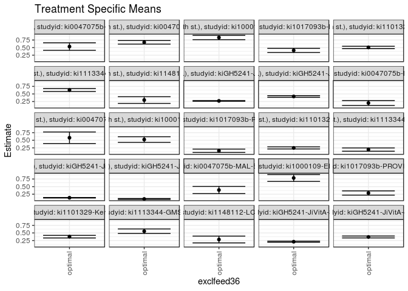

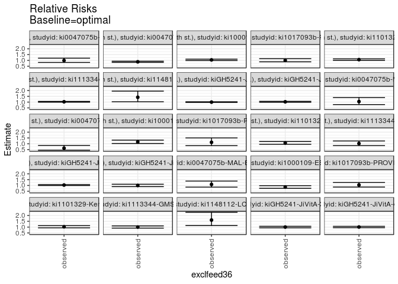

## Results Table

### Parameter: TSM

| agecat | studyid | country | intervention_level | baseline_level | estimate | ci_lower | ci_upper |
| --- | --- | --- | --- | --- | --- | --- | --- |
| 0-24 months (no birth st.) | ki0047075b-MAL-ED | BANGLADESH | optimal | NA | 0.5341437 | 0.4100819 | 0.6582055 |
| 0-24 months (no birth st.) | ki0047075b-MAL-ED | PERU | optimal | NA | 0.6757380 | 0.6157246 | 0.7357514 |
| 0-24 months (no birth st.) | ki1000109-EE | PAKISTAN | optimal | NA | 0.8309331 | 0.7596967 | 0.9021696 |
| 0-24 months (no birth st.) | ki1017093b-PROVIDE | BANGLADESH | optimal | NA | 0.4081323 | 0.3391470 | 0.4771177 |
| 0-24 months (no birth st.) | ki1101329-Keneba | GAMBIA | optimal | NA | 0.5046531 | 0.4652260 | 0.5440801 |
| 0-24 months (no birth st.) | ki1113344-GMS-Nepal | NEPAL | optimal | NA | 0.6291202 | 0.5808642 | 0.6773762 |
| 0-24 months (no birth st.) | ki1148112-LCNI-5 | MALAWI | optimal | NA | 0.2987513 | 0.1887156 | 0.4087869 |
| 0-24 months (no birth st.) | kiGH5241-JiVitA-3 | BANGLADESH | optimal | NA | 0.2704728 | 0.2579908 | 0.2829549 |
| 0-24 months (no birth st.) | kiGH5241-JiVitA-4 | BANGLADESH | optimal | NA | 0.4172889 | 0.3901114 | 0.4444663 |
| 0-6 months (no birth st.) | ki0047075b-MAL-ED | BANGLADESH | optimal | NA | 0.2013342 | 0.1206815 | 0.2819868 |
| 0-6 months (no birth st.) | ki0047075b-MAL-ED | PERU | optimal | NA | 0.5824159 | 0.3921569 | 0.7726750 |
| 0-6 months (no birth st.) | ki1000109-EE | PAKISTAN | optimal | NA | 0.5244238 | 0.4325493 | 0.6162983 |
| 0-6 months (no birth st.) | ki1017093b-PROVIDE | BANGLADESH | optimal | NA | 0.1541084 | 0.0996096 | 0.2086072 |
| 0-6 months (no birth st.) | ki1101329-Keneba | GAMBIA | optimal | NA | 0.2485772 | 0.2141267 | 0.2830277 |
| 0-6 months (no birth st.) | ki1113344-GMS-Nepal | NEPAL | optimal | NA | 0.1939309 | 0.1404033 | 0.2474585 |
| 0-6 months (no birth st.) | kiGH5241-JiVitA-3 | BANGLADESH | optimal | NA | 0.1334822 | 0.1250222 | 0.1419422 |
| 0-6 months (no birth st.) | kiGH5241-JiVitA-4 | BANGLADESH | optimal | NA | 0.0931178 | 0.0777826 | 0.1084530 |
| 6-24 months | ki0047075b-MAL-ED | BANGLADESH | optimal | NA | 0.3878216 | 0.2692596 | 0.5063837 |
| 6-24 months | ki1000109-EE | PAKISTAN | optimal | NA | 0.7844089 | 0.6709701 | 0.8978477 |
| 6-24 months | ki1017093b-PROVIDE | BANGLADESH | optimal | NA | 0.2890596 | 0.2187721 | 0.3593471 |
| 6-24 months | ki1101329-Keneba | GAMBIA | optimal | NA | 0.3775751 | 0.3345582 | 0.4205920 |
| 6-24 months | ki1113344-GMS-Nepal | NEPAL | optimal | NA | 0.5573860 | 0.4829325 | 0.6318396 |
| 6-24 months | ki1148112-LCNI-5 | MALAWI | optimal | NA | 0.2843371 | 0.1721738 | 0.3965003 |
| 6-24 months | kiGH5241-JiVitA-3 | BANGLADESH | optimal | NA | 0.2117665 | 0.1939471 | 0.2295859 |
| 6-24 months | kiGH5241-JiVitA-4 | BANGLADESH | optimal | NA | 0.3674820 | 0.3360974 | 0.3988667 |

### Parameter: E(Y)

| agecat | studyid | country | intervention_level | baseline_level | estimate | ci_lower | ci_upper |
| --- | --- | --- | --- | --- | --- | --- | --- |
| 0-24 months (no birth st.) | ki0047075b-MAL-ED | BANGLADESH | observed | NA | 0.5311005 | 0.4632825 | 0.5989184 |
| 0-24 months (no birth st.) | ki0047075b-MAL-ED | PERU | observed | NA | 0.5952381 | 0.5345146 | 0.6559615 |
| 0-24 months (no birth st.) | ki1000109-EE | PAKISTAN | observed | NA | 0.8693878 | 0.8271061 | 0.9116694 |
| 0-24 months (no birth st.) | ki1017093b-PROVIDE | BANGLADESH | observed | NA | 0.4107452 | 0.3705685 | 0.4509220 |
| 0-24 months (no birth st.) | ki1101329-Keneba | GAMBIA | observed | NA | 0.5389321 | 0.5158847 | 0.5619796 |
| 0-24 months (no birth st.) | ki1113344-GMS-Nepal | NEPAL | observed | NA | 0.6455696 | 0.6024620 | 0.6886773 |
| 0-24 months (no birth st.) | ki1148112-LCNI-5 | MALAWI | observed | NA | 0.4228571 | 0.3494545 | 0.4962598 |
| 0-24 months (no birth st.) | kiGH5241-JiVitA-3 | BANGLADESH | observed | NA | 0.2699052 | 0.2606917 | 0.2791188 |
| 0-24 months (no birth st.) | kiGH5241-JiVitA-4 | BANGLADESH | observed | NA | 0.4276032 | 0.4069572 | 0.4482492 |
| 0-6 months (no birth st.) | ki0047075b-MAL-ED | BANGLADESH | observed | NA | 0.2105263 | 0.1551227 | 0.2659300 |
| 0-6 months (no birth st.) | ki0047075b-MAL-ED | PERU | observed | NA | 0.3611111 | 0.3016895 | 0.4205327 |
| 0-6 months (no birth st.) | ki1000109-EE | PAKISTAN | observed | NA | 0.6081633 | 0.5469119 | 0.6694146 |
| 0-6 months (no birth st.) | ki1017093b-PROVIDE | BANGLADESH | observed | NA | 0.1733102 | 0.1423987 | 0.2042217 |
| 0-6 months (no birth st.) | ki1101329-Keneba | GAMBIA | observed | NA | 0.2652948 | 0.2448823 | 0.2857072 |
| 0-6 months (no birth st.) | ki1113344-GMS-Nepal | NEPAL | observed | NA | 0.1983122 | 0.1623791 | 0.2342454 |
| 0-6 months (no birth st.) | kiGH5241-JiVitA-3 | BANGLADESH | observed | NA | 0.1379748 | 0.1313000 | 0.1446495 |
| 0-6 months (no birth st.) | kiGH5241-JiVitA-4 | BANGLADESH | observed | NA | 0.0927295 | 0.0806900 | 0.1047690 |
| 6-24 months | ki0047075b-MAL-ED | BANGLADESH | observed | NA | 0.4213836 | 0.3443902 | 0.4983771 |
| 6-24 months | ki1000109-EE | PAKISTAN | observed | NA | 0.6736842 | 0.5789010 | 0.7684674 |
| 6-24 months | ki1017093b-PROVIDE | BANGLADESH | observed | NA | 0.3004386 | 0.2583143 | 0.3425629 |
| 6-24 months | ki1101329-Keneba | GAMBIA | observed | NA | 0.3877069 | 0.3608893 | 0.4145245 |
| 6-24 months | ki1113344-GMS-Nepal | NEPAL | observed | NA | 0.5593668 | 0.5093185 | 0.6094150 |
| 6-24 months | ki1148112-LCNI-5 | MALAWI | observed | NA | 0.4567901 | 0.3798457 | 0.5337346 |
| 6-24 months | kiGH5241-JiVitA-3 | BANGLADESH | observed | NA | 0.2122010 | 0.2018013 | 0.2226006 |
| 6-24 months | kiGH5241-JiVitA-4 | BANGLADESH | observed | NA | 0.3704082 | 0.3493754 | 0.3914410 |

### Parameter: RR

| agecat | studyid | country | intervention_level | baseline_level | estimate | ci_lower | ci_upper |
| --- | --- | --- | --- | --- | --- | --- | --- |
| 0-24 months (no birth st.) | ki0047075b-MAL-ED | BANGLADESH | observed | optimal | 0.9943027 | 0.8275010 | 1.1947271 |
| 0-24 months (no birth st.) | ki0047075b-MAL-ED | PERU | observed | optimal | 0.8808712 | 0.8326494 | 0.9318856 |
| 0-24 months (no birth st.) | ki1000109-EE | PAKISTAN | observed | optimal | 1.0462788 | 0.9864977 | 1.1096827 |
| 0-24 months (no birth st.) | ki1017093b-PROVIDE | BANGLADESH | observed | optimal | 1.0064022 | 0.8810073 | 1.1496446 |
| 0-24 months (no birth st.) | ki1101329-Keneba | GAMBIA | observed | optimal | 1.0679260 | 1.0025411 | 1.1375753 |
| 0-24 months (no birth st.) | ki1113344-GMS-Nepal | NEPAL | observed | optimal | 1.0261467 | 0.9941564 | 1.0591664 |
| 0-24 months (no birth st.) | ki1148112-LCNI-5 | MALAWI | observed | optimal | 1.4154154 | 1.0301646 | 1.9447387 |
| 0-24 months (no birth st.) | kiGH5241-JiVitA-3 | BANGLADESH | observed | optimal | 0.9979015 | 0.9680936 | 1.0286273 |
| 0-24 months (no birth st.) | kiGH5241-JiVitA-4 | BANGLADESH | observed | optimal | 1.0247175 | 0.9840618 | 1.0670529 |
| 0-6 months (no birth st.) | ki0047075b-MAL-ED | BANGLADESH | observed | optimal | 1.0456561 | 0.7846250 | 1.3935277 |
| 0-6 months (no birth st.) | ki0047075b-MAL-ED | PERU | observed | optimal | 0.6200227 | 0.4483285 | 0.8574698 |
| 0-6 months (no birth st.) | ki1000109-EE | PAKISTAN | observed | optimal | 1.1596790 | 1.0229815 | 1.3146430 |
| 0-6 months (no birth st.) | ki1017093b-PROVIDE | BANGLADESH | observed | optimal | 1.1245993 | 0.8406772 | 1.5044106 |
| 0-6 months (no birth st.) | ki1101329-Keneba | GAMBIA | observed | optimal | 1.0672532 | 0.9525791 | 1.1957320 |
| 0-6 months (no birth st.) | ki1113344-GMS-Nepal | NEPAL | observed | optimal | 1.0225923 | 0.8447438 | 1.2378841 |
| 0-6 months (no birth st.) | kiGH5241-JiVitA-3 | BANGLADESH | observed | optimal | 1.0336567 | 0.9930291 | 1.0759464 |
| 0-6 months (no birth st.) | kiGH5241-JiVitA-4 | BANGLADESH | observed | optimal | 0.9958298 | 0.8988600 | 1.1032608 |
| 6-24 months | ki0047075b-MAL-ED | BANGLADESH | observed | optimal | 1.0865398 | 0.8575826 | 1.3766240 |
| 6-24 months | ki1000109-EE | PAKISTAN | observed | optimal | 0.8588432 | 0.7530731 | 0.9794689 |
| 6-24 months | ki1017093b-PROVIDE | BANGLADESH | observed | optimal | 1.0393656 | 0.8614194 | 1.2540707 |
| 6-24 months | ki1101329-Keneba | GAMBIA | observed | optimal | 1.0268338 | 0.9364556 | 1.1259345 |
| 6-24 months | ki1113344-GMS-Nepal | NEPAL | observed | optimal | 1.0035536 | 0.9125169 | 1.1036725 |
| 6-24 months | ki1148112-LCNI-5 | MALAWI | observed | optimal | 1.6065093 | 1.1345972 | 2.2747034 |
| 6-24 months | kiGH5241-JiVitA-3 | BANGLADESH | observed | optimal | 1.0020516 | 0.9381936 | 1.0702561 |
| 6-24 months | kiGH5241-JiVitA-4 | BANGLADESH | observed | optimal | 1.0079626 | 0.9499545 | 1.0695129 |

### Parameter: PAR

| agecat | studyid | country | intervention_level | baseline_level | estimate | ci_lower | ci_upper |
| --- | --- | --- | --- | --- | --- | --- | --- |
| 0-24 months (no birth st.) | ki0047075b-MAL-ED | BANGLADESH | optimal | NA | -0.0030432 | -0.1011620 | 0.0950756 |
| 0-24 months (no birth st.) | ki0047075b-MAL-ED | PERU | optimal | NA | -0.0804999 | -0.1152166 | -0.0457831 |
| 0-24 months (no birth st.) | ki1000109-EE | PAKISTAN | optimal | NA | 0.0384546 | -0.0099685 | 0.0868778 |
| 0-24 months (no birth st.) | ki1017093b-PROVIDE | BANGLADESH | optimal | NA | 0.0026129 | -0.0516856 | 0.0569114 |
| 0-24 months (no birth st.) | ki1101329-Keneba | GAMBIA | optimal | NA | 0.0342791 | 0.0024380 | 0.0661202 |
| 0-24 months (no birth st.) | ki1113344-GMS-Nepal | NEPAL | optimal | NA | 0.0164494 | -0.0033964 | 0.0362952 |
| 0-24 months (no birth st.) | ki1148112-LCNI-5 | MALAWI | optimal | NA | 0.1241059 | 0.0276553 | 0.2205565 |
| 0-24 months (no birth st.) | kiGH5241-JiVitA-3 | BANGLADESH | optimal | NA | -0.0005676 | -0.0087703 | 0.0076352 |
| 0-24 months (no birth st.) | kiGH5241-JiVitA-4 | BANGLADESH | optimal | NA | 0.0103143 | -0.0065517 | 0.0271804 |
| 0-6 months (no birth st.) | ki0047075b-MAL-ED | BANGLADESH | optimal | NA | 0.0091921 | -0.0485405 | 0.0669248 |
| 0-6 months (no birth st.) | ki0047075b-MAL-ED | PERU | optimal | NA | -0.2213048 | -0.4048811 | -0.0377285 |
| 0-6 months (no birth st.) | ki1000109-EE | PAKISTAN | optimal | NA | 0.0837395 | 0.0190417 | 0.1484373 |
| 0-6 months (no birth st.) | ki1017093b-PROVIDE | BANGLADESH | optimal | NA | 0.0192018 | -0.0254871 | 0.0638907 |
| 0-6 months (no birth st.) | ki1101329-Keneba | GAMBIA | optimal | NA | 0.0167176 | -0.0115406 | 0.0449758 |
| 0-6 months (no birth st.) | ki1113344-GMS-Nepal | NEPAL | optimal | NA | 0.0043813 | -0.0326016 | 0.0413642 |
| 0-6 months (no birth st.) | kiGH5241-JiVitA-3 | BANGLADESH | optimal | NA | 0.0044926 | -0.0008604 | 0.0098455 |
| 0-6 months (no birth st.) | kiGH5241-JiVitA-4 | BANGLADESH | optimal | NA | -0.0003883 | -0.0099278 | 0.0091512 |
| 6-24 months | ki0047075b-MAL-ED | BANGLADESH | optimal | NA | 0.0335620 | -0.0581262 | 0.1252502 |
| 6-24 months | ki1000109-EE | PAKISTAN | optimal | NA | -0.1107247 | -0.2080249 | -0.0134244 |
| 6-24 months | ki1017093b-PROVIDE | BANGLADESH | optimal | NA | 0.0113790 | -0.0427978 | 0.0655558 |
| 6-24 months | ki1101329-Keneba | GAMBIA | optimal | NA | 0.0101318 | -0.0246786 | 0.0449422 |
| 6-24 months | ki1113344-GMS-Nepal | NEPAL | optimal | NA | 0.0019807 | -0.0510165 | 0.0549779 |
| 6-24 months | ki1148112-LCNI-5 | MALAWI | optimal | NA | 0.1724531 | 0.0708910 | 0.2740151 |
| 6-24 months | kiGH5241-JiVitA-3 | BANGLADESH | optimal | NA | 0.0004345 | -0.0135089 | 0.0143779 |
| 6-24 months | kiGH5241-JiVitA-4 | BANGLADESH | optimal | NA | 0.0029261 | -0.0188423 | 0.0246945 |

### Parameter: PAF

| agecat | studyid | country | intervention_level | baseline_level | estimate | ci_lower | ci_upper |
| --- | --- | --- | --- | --- | --- | --- | --- |
| 0-24 months (no birth st.) | ki0047075b-MAL-ED | BANGLADESH | optimal | NA | -0.0057299 | -0.2084578 | 0.1629888 |
| 0-24 months (no birth st.) | ki0047075b-MAL-ED | PERU | optimal | NA | -0.1352398 | -0.2009857 | -0.0730930 |
| 0-24 months (no birth st.) | ki1000109-EE | PAKISTAN | optimal | NA | 0.0442318 | -0.0136871 | 0.0988415 |
| 0-24 months (no birth st.) | ki1017093b-PROVIDE | BANGLADESH | optimal | NA | 0.0063614 | -0.1350643 | 0.1301660 |
| 0-24 months (no birth st.) | ki1101329-Keneba | GAMBIA | optimal | NA | 0.0636056 | 0.0025347 | 0.1209373 |
| 0-24 months (no birth st.) | ki1113344-GMS-Nepal | NEPAL | optimal | NA | 0.0254805 | -0.0058779 | 0.0558613 |
| 0-24 months (no birth st.) | ki1148112-LCNI-5 | MALAWI | optimal | NA | 0.2934936 | 0.0292813 | 0.4857921 |
| 0-24 months (no birth st.) | kiGH5241-JiVitA-3 | BANGLADESH | optimal | NA | -0.0021029 | -0.0329580 | 0.0278306 |
| 0-24 months (no birth st.) | kiGH5241-JiVitA-4 | BANGLADESH | optimal | NA | 0.0241213 | -0.0161963 | 0.0628393 |
| 0-6 months (no birth st.) | ki0047075b-MAL-ED | BANGLADESH | optimal | NA | 0.0436626 | -0.2744941 | 0.2823967 |
| 0-6 months (no birth st.) | ki0047075b-MAL-ED | PERU | optimal | NA | -0.6128441 | -1.2305073 | -0.1662218 |
| 0-6 months (no birth st.) | ki1000109-EE | PAKISTAN | optimal | NA | 0.1376924 | 0.0224652 | 0.2393372 |
| 0-6 months (no birth st.) | ki1017093b-PROVIDE | BANGLADESH | optimal | NA | 0.1107944 | -0.1895172 | 0.3352878 |
| 0-6 months (no birth st.) | ki1101329-Keneba | GAMBIA | optimal | NA | 0.0630152 | -0.0497816 | 0.1636922 |
| 0-6 months (no birth st.) | ki1113344-GMS-Nepal | NEPAL | optimal | NA | 0.0220931 | -0.1837909 | 0.1921699 |
| 0-6 months (no birth st.) | kiGH5241-JiVitA-3 | BANGLADESH | optimal | NA | 0.0325608 | -0.0070199 | 0.0705857 |
| 0-6 months (no birth st.) | kiGH5241-JiVitA-4 | BANGLADESH | optimal | NA | -0.0041876 | -0.1125203 | 0.0935960 |
| 6-24 months | ki0047075b-MAL-ED | BANGLADESH | optimal | NA | 0.0796471 | -0.1660685 | 0.2735852 |
| 6-24 months | ki1000109-EE | PAKISTAN | optimal | NA | -0.1643569 | -0.3278924 | -0.0209615 |
| 6-24 months | ki1017093b-PROVIDE | BANGLADESH | optimal | NA | 0.0378746 | -0.1608747 | 0.2025968 |
| 6-24 months | ki1101329-Keneba | GAMBIA | optimal | NA | 0.0261325 | -0.0678563 | 0.1118488 |
| 6-24 months | ki1113344-GMS-Nepal | NEPAL | optimal | NA | 0.0035410 | -0.0958702 | 0.0939341 |
| 6-24 months | ki1148112-LCNI-5 | MALAWI | optimal | NA | 0.3775324 | 0.1186299 | 0.5603822 |
| 6-24 months | kiGH5241-JiVitA-3 | BANGLADESH | optimal | NA | 0.0020474 | -0.0658781 | 0.0656442 |
| 6-24 months | kiGH5241-JiVitA-4 | BANGLADESH | optimal | NA | 0.0078997 | -0.0526820 | 0.0649949 |